# VR-Training Project

Arsine Chinaryan, Anh Hoang Minh Dang, Iris Dizdari, Margarita Khachatryan

Dr. Fabian Scheipl, Dr. Sabine Hoffmann, Daniel Schlichting

2024-02-13

## Outline

**1. Overview & Terminology**

- VR-Project
- Description of data sets
- Terminology
- Analytical questions

**2. Data Analysis**

- Cohorts comparison: Similarities and Differences
- Relationship between Stress indicators and Physiological Measurements
- Relationship over the rounds
- Subgroups and Outliers

**3. Summary**

## Outline

**1. Overview & Terminology**

- VR-Project
- Description of data sets
- Terminology
- Analytical questions

**2. Data Analysis**

**3. Summary**

## Overview of the VR Project

**VR-Training**: Adapting Virtual Reality Training Applications by Dynamically Adjusting Visual Aspects

**Motivation:**  
- Static training doesn’t fit everyone: Too easy → boredom, Too hard → anxiety  
- Adaptive VR training balances difficulty to improve outcomes.

**Scenario:**  
- Users move and place parcels in a VR warehouse using controllers.  
- Visual cues: dynamic lighting and color guidance.

**Adaptive Features:**  
- Tracks user behavior (head movement) and performance (time, errors).  
- Adjusts lighting, object colors, etc., after each training round.

## Description of data sets

- **Survey**: Cross-sectional study with longitudinal elements
- **2 Cohorts: Linne and Dame**
  - 20 participants in Linne, 80 participants in Dame
  - 9 rounds of training
  - 3 groups of training versions: Adaptive, Non-Adaptive, Control
- **Analyzed data:**
  - Demographic data: Gender, Age, Weight, Height
  - Stress indicators
  - Physiological measurement data (PMD)

## Terminology

### Stress indicators:

- Cognitive load (1 to 6 with 1 very low and 6 very high)
- Physical load (1 to 6 with 1 very low and 6 very high)

### Physiological Measurement Data (PMD)

- **Heart measurements:** Heart rate (HR), SDNN, RMSSD
- **Skin conductance response (SCR) measurements:** Skin conductance level (SCL), SCR frequency, SCR amplitude, SCR rising time
- **Eye tracking measurements:** Blink rate per minute, Saccade amplitude, Saccade velocity

## Analytical questions

1. Are there differences between the 2 data cohorts, Linne and Dame?
2. How are the stress indicators and the physiological measurements related?
3. Does this correlation change over the rounds?
4. Are there subgroups within the test subjects that stand out from the rest?

## Outline

**1. Overview & Terminology**

**2. Data Analysis**

- Cohorts comparison: Similarities and Differences  
  - Relationship between Stress indicators and Physiological Measurements  
  - Relationship over the rounds  
  - Subgroups and Outliers

**3. Summary**

## Outline

**1. Overview & Terminology**

**2. Data Analysis**

- Cohorts comparison: Similarities and Differences  
- Relationship between Stress indicators and Physiological Measurements  
- Relationship over the rounds  
- Subgroups and Outliers

**3. Summary**

## Relationship between Stress indicators and Physiological Measurements

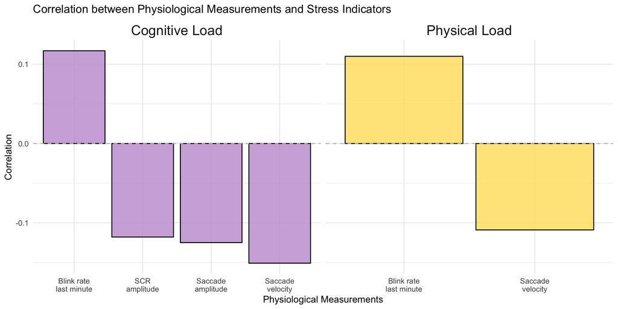

## Analytical questions

**2. How are the stress indicators and the physiological measurements related?**

- Positive correlation: Blink rate
- Negative correlation: Saccade velocity

⇒ Values of the correlation vary from -0.15 to 0.1, indicating very weak relationship between the stress indicators and the physiological measurements

## Outline

**1. Overview & Terminology**

**2. Data Analysis**

- Cohorts comparison: Similarities and Differences  
- Relationship between Stress indicators and Physiological Measurements  
- Relationship over the rounds  
- Subgroups and Outliers

**3. Summary**

## Outline

**1. Overview & Terminology**

**2. Data Analysis**

- Cohorts comparison: Similarities and Differences  
- Relationship between Stress indicators and Physiological Measurements  
- Relationship over the rounds  
- Subgroups and Outliers

**3. Summary**

## Outline

**1. Overview & Terminology**

**2. Data Analysis**

**3. Summary**